# How Australian places are represented in Wikipedia

The Annual Report of the Wikihistories Project

Authors

Affiliations

Francesca Sidoti

University of Technology, Sydney

[Michael Falk](https://findanexpert.unimelb.edu.au/profile/1043380-michael-falk)

University of Melbourne

[Heather Ford](https://hblog.org/)

University of Technology, Sydney

[Tamson Pietsch](https://capandgown.wordpress.com/)

University of Technology, Sydney

[Tom Byers](https://tom-byers.com)

University of Melbourne

Published

July 1, 2024

Keywords

Wikipedia, historiography, Australia, digital humanities, systemic bias, historical geography

## Frequently Asked Questions

### Which Australian places are most contentious?

| Article | Edits | Reverts | Reverts per Edit |
| --- | --- | --- | --- |
| [Barmah National Park](https://en.wikipedia.org/wiki/Barmah_National_Park) | 70 | 39 | 0.5571429 |
| [Home Hill, Queensland](https://en.wikipedia.org/wiki/Home_Hill,_Queensland) | 161 | 81 | 0.5031056 |
| [Giru, Queensland](https://en.wikipedia.org/wiki/Giru,_Queensland) | 57 | 28 | 0.4912281 |
| [Repatriation General Hospital, Daw Park](https://en.wikipedia.org/wiki/Repatriation_General_Hospital,_Daw_Park) | 37 | 18 | 0.4864865 |
| [Howard Springs, Northern Territory](https://en.wikipedia.org/wiki/Howard_Springs,_Northern_Territory) | 76 | 36 | 0.4736842 |
| [Nigger Head](https://en.wikipedia.org/wiki/Nigger_Head) | 163 | 76 | 0.4662577 |
| [Inkerman, Queensland](https://en.wikipedia.org/wiki/Inkerman,_Queensland) | 39 | 18 | 0.4615385 |
| [Dandenong Ranges National Park](https://en.wikipedia.org/wiki/Dandenong_Ranges_National_Park) | 105 | 46 | 0.4380952 |
| [Chinderah, New South Wales](https://en.wikipedia.org/wiki/Chinderah,_New_South_Wales) | 47 | 20 | 0.4255319 |
| Airport Drive (Melbourne) | 55 | 21 | 0.3818182 |

Some Wikipedia pages are more controversial than others. Wikipedia contributors have argued for years over whether Pavolva was invented in Australia or New Zealand. By contrast, the page for the Pacific Highway has inspired virtually no debate. It is not easy to locate or rank contentious articles using computerised methods. Contention can take many forms: editors might ‘revert’ (i.e. undo) one another’s edits; they might debate topics in-depth on Wikipedia Talk pages; they might abuse one another ‘off-wiki’; they might accuse one another of misconduct, and be subject to adminstrative redress. For simplicity’s sake, we focus just on the first manifestation of contention, when Wikipedians ‘revert’ or undo each others’ edits.

As these few examples demonstrate, Australian places can inspire many kinds of dispute: disputes about Australia’s colonisation, disputes about civil liberties, disputes about arid matters of geographical fact. They can also inspire simple vandalism, sometimes of a rather unsavoury kind, as in the case of [Nigger Head](https://en.wikipedia.org/wiki/Nigger_Head), which pranksters delight to edit with racist slurs and absurd jokes.

### Which language edition has the most Australian places?

[figure not shown]

Figure 2: The Cebuano and Swedish Wikipedias have many articles written by a software program, lsjbot. Swedish Wikipedians have in recent years deleted most of lsjbot’s articles, but the small community of Cebuano editors in the Philippines have not done so in their encyclopaedia.

Wikipedia is available in more than 300 languages. You might expect that English Wikipedia would have the most articles about Australian places—but you’d be wrong. Figure 2 shows that [Cebuano Wikipedia](https://ceb.wikipedia.org) has by far the largest number of articles about Australian places. Tens of thousands of Australian places, such as [Molecap Hill](https://ceb.wikipedia.org/wiki/Molecap_Hill), [Dindum Island](https://ceb.wikipedia.org/wiki/Dindum_Island) and [Mount Finlayson Range](https://ceb.wikipedia.org/wiki/Mount_Finlayson_Range), have articles *only* in Cebuano Wikipedia. Why is this?

It is *not* because the speakers of the [Cebuano language](https://en.wikipedia.org/wiki/Cebuano_language) in Philippines are obsessed with Australian geography. It is because virtually the whole Cebuano Wikipedia has been written by a bot, [lsjbot](https://en.wikipedia.org/wiki/Lsjbot), programmed by [Sverker Johansson](https://en.wikipedia.org/wiki/Sverker_Johansson), a Swedish computational linguist. `lsjbot` was historically responsible for a large portion of Swedish Wikipedia too, and despite efforts by Swedish Wikipedians to delete its formulaic articles, `lsjbot` is still responsible for many Swedish articles about obscure Australian places, including [Dawes National Park](https://sv.wikipedia.org/wiki/Dawes_nationalpark) and [Lake Baker](https://sv.wikipedia.org/wiki/Lake_Baker). The story is similar on [Egyptian Arabic Wikipedia](https://arz.wikipedia.org/wiki/%D8%A7%D9%84%D8%B5%D9%81%D8%AD%D9%87_%D8%A7%D9%84%D8%B1%D8%A6%D9%8A%D8%B3%D9%8A%D9%87). Egyptian Arabic Wikipedia contains thousands of articles about Australian places because of one editor, [Mahar Asaad Baker](https://arz.wikipedia.org/wiki/%D9%85%D8%B3%D8%AA%D8%AE%D8%AF%D9%85:HitomiAkane), who describes [in a published booklet](https://search.worldcat.org/title/1341182226) how they wrote 1.6 million articles by downloading data from Wikidata and converting it into Masri text for the site.

How is it possible for simple software to generate so many factually accurate articles about Australian places? Read any article by `lsjbot`, and you will see how thoroughly geography has been ‘datified’ in the 21st century. A global database, geonames.org records basic data about millions of place names. `lsjbot` browses geonames.org to find places without Wikipedia articles. When it finds a missing article, `lsjbot` extracts basic information from geonames.org, such as the type, name, and co-ordinates of the place. The bot then combines the basic information with publicly-available climate data from [NASA Earth Observations datasets](https://neo.gsfc.nasa.gov/dataset_index.php), and uses [this climatic map](https://hess.copernicus.org/articles/11/1633/2007/) to determine the place’s [Köppen climate classification](https://en.wikipedia.org/wiki/K%C3%B6ppen_climate_classification).[^1] These big geographical databases don’t really reflect the interests of human readers and writers, as we will see in the next question…

### What kinds of places get most attention from editors?

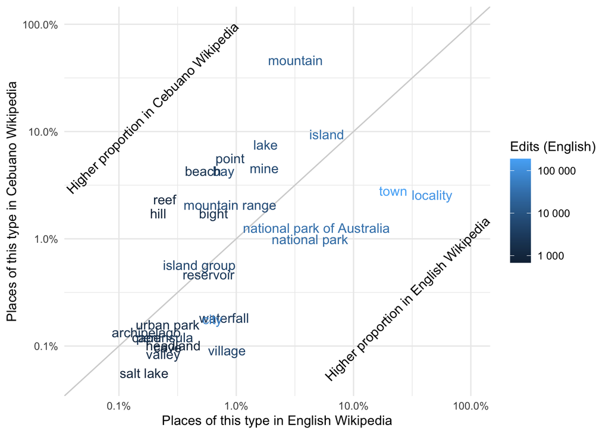

Figure 3: This shows all the types of places that have at least ten articles about them in English and Cebuano Wikipedia. The types are positioned on the graph according to the percentage of articles of that type in the dataset. Types below the line have a higher proportion in English Wikipedia than in Cebuano Wikipedia, and vice-versa. The brighter blue the label, the more often places of that type have been edited in English Wikipedia.

If we compare Cebuano and English Wikipedias, we see that human and bot editors have different priorities. Broadly speaking, Cebuano Wikipedia is bot-authored, while English Wikipedia is human-authored.[^2] In English Wikipedia, places of human occupation make up a bigger proportion of the total. Towns, localities, cities, urban parks and villages all make up a larger proportion of the place articles in English Wikipedia than in Cebuano Wikipedia. By contrast, in bot-authored Cebuano Wikipedia, geographical features such as mountains, lakes, bights and hills make up a much larger share of the Australian Place articles. This difference is is even more pronounced when we consider edit statistics on English Wikipedia. Consider articles about cities. Cities account for only 0.63% of the Australian places on English Wikipedia (0.18% in Cebuano ones), but they have received 12% of the human edits. Not only are human editors more likely to create articles about places with a strong human connection. They are also more likely to spend their time editing them.

English Wikipedia is strongly anthropocentric, at least compared to the geographical databases that form the basis of bot-authored Cebuano Wikipedia. English Wikipedia prioritises human over physical geography.

### Who reads the articles about Australian places?

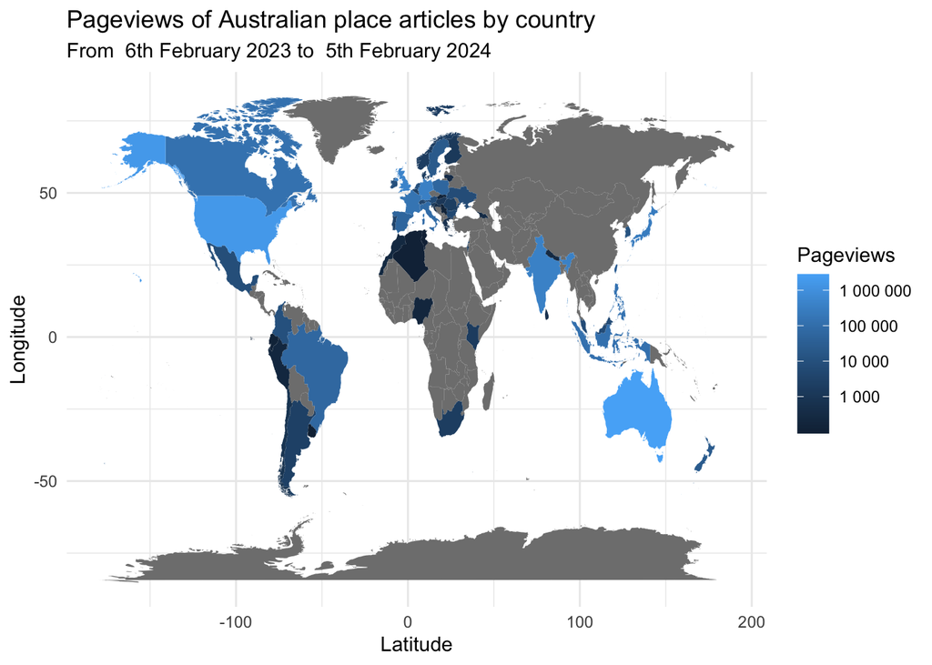

## Footnotes

[^1]: If you know the C# programming language, you can see how `lsjbot` does all this [here](https://github.com/Lsjbot/make-geonames/blob/master/Program.cs).
[^2]: Bots do play numerous important roles on English Wikipedia, but their role in article-creation is far more limited than on Cebuano Wikipedia.